# Шаблон кода для задачи кластеризации

Константин Житков

## О чем эта заметка?

Несколько раз на работе требовалось сделать кластерный анализ российских университетов. В этой заметке собран основной код, которым я пользовалься в таких задачах. Первая часть посвящена разведывательному анализу данных, вторая связана с самим построением кластеров.

## Разведывательный анализ

### Диаграмма рассеивания

Чтобы наглядно изучить корреляции будем использовать небольшую обёртку для функции `GGally::ggpairs`. Наша функция находит все уникальные комбинации из названий двух колонок, а затем строит диаграмму рассеивания, плотности каждой переменной, а также считает корреляцию.

```r
scatterComb <- function(data, n_plots = 2, ...) {
  # Get all unique combinations of column names
  combinations <- combn(colnames(data), n_plots)

  # Plot scatterplots
  scatter_list <- lapply(1:ncol(combinations), function(x)
    GGally::ggpairs(data[, colnames(data) %in% combinations[ , x]],
            title = paste(combinations[1, x], combinations[2, x]),
            ...)
    + theme_bw())

  return(scatter_list)
}
```

Результат удобно сохранить, используя `lapply` и `ggsave` (предположим, что диаграммы были сохранены в объект `scatters`):

```r
lapply(1:length(scatters),
       function(x) ggsave(paste0("plots/", scatters[[x]]$title),
                                              scatters[[x]]))
```

#### Пример результата

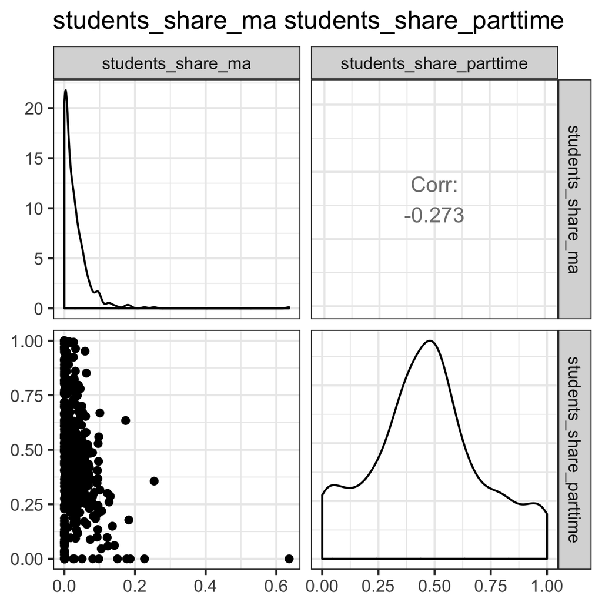

### Гистограммы

Самым простым способом найти переменные, которые принимают мало уникальных значений, является построение гистограмм. Разобьём задачу на 2 этапа: написание функции для построения гистограмм и сохранение созданных картинок в приемлимом числе файлов.

```r
hist_plotter <- function(data, variable, bins = 30) {
  pl <- ggplot2::ggplot(data = data, aes_string(x = variable)) +
    # Function to plot histogram
    #
    # Pass variable name as a string
    #
    # Returns: ggplot object
    geom_histogram(color = "grey30", fill = "white", bins = bins) +
    labs(title = variable) +
    theme_bw() +
    theme(plot.title = element_text(size = 14, hjust = 0.5))
  return(pl)
}
```

Допустим в наборе данных 120 переменных. Чтобы сократить число файлов, сделаем так, чтобы на одной картинке помещалось сразу 6 гистограмм. Сначала создаём гистограммы:

```r
hists <- lapply(1:120, function(x) hist_plotter(data, data[, x], bins = 10))
```

Пишем вспомогательную функцию для того, чтобы расположить гистограммы на «решетке» и сразу применяем её к листу, содержащему графики:

```r
gridRanger <- function(x, y) {
  # Function takes list's range of indices as input
  #
  # Note on do.call: do.call calls a function ONCE,
  # but it's arguments are supplied in list
  pl <- do.call("grid.arrange", c(hists[x:y], ncol = 2))
  return(pl)
}

grids <- Map(gridRanger, seq(1, 120, 6), seq(6, 120, 6))
```

Сохраняем в папку explor_hists:

```r
for (i in 1:length(grids)) {
  ggsave(paste0("explor_hists/", "h_", i, ".png"), grids[[i]], width = 22, height = 30, unit = "cm")
}
```

#### Пример результата

[figure not shown]

## Кластеризация

Выбирая метод кластеризации, также как и с МНК, необходимо помнить о предпосылках для применения алгоритма. Допустим популярный алгоритм [K-means](http://varianceexplained.org/r/kmeans-free-lunch/) требует, чтобы данные были форма распределения данных была сферической и каждый кластер состоял из примерно одинакового числа точек. В нашем случае мы сразу замечаем, что не можем ожидать примерно одинакого распредления вузов по кластерам: очевидно, что существует группа вузов лидеров, которая будет значительно меньше группы, настроенной, к примеру, на дистанционное образование. Помимо этого мы ожидаем иерархическую структуру данных: вузы можно поделить сначала по качеству приёма, а среди них уже выделить технические вузы, гуманитарные и другие.

### Подготовка данных. Нормализация:

```r
norm_data <- sapply(1:ncol(me_clust), function(x) {
  (me_clust[, x] - min(me_clust[, x])) / (max(me_clust[, x]) - min(me_clust[, x]))})
```

### Строим кластеры

Если все данные числовые, поэтому пользуемся стандартной евклидовой метрикой. Критерий «сливания» кластеров на втором и последующем этапах выбран в соответствии с литературой по кластеризации вузов. Его смысл заключается в том, чтобы найти такое объединение кластеров, при котором внутренняя дисперсия нового большого кластера будет минимальной.

```r
# Compute distances
me_dists <- dist(me_clust, method = "euclidean")

# Compute clusters:
hc_fit <- hclust(me_dists, method = "ward.D2")
```

### Результат

Сохраняем несколько возможных вариантов разбиения выборки на кластеры в один датафрэйм:

```r
# Create cluster matrix
clusters <- lapply(2:10, function(x) cutree(hc_fit, x))

# Create dataframe with initial data and cluster distributions for further analysis
clusters_uniID <- Reduce(cbind, list(me_clust,
                                     setNames(clusters, paste0("cluster", 2:(length(clusters) + 1)))))
```